# GGIS 224 - Lab 3

Your name, Environmental Data Science @UIUC

## Overview

In this assignment, we’ll explore a dataset of environmental features in the City of Chicago. Along the way, you’ll hone in on key themes learned from the first three weeks of our class. You’ll specifically review:

- Data Inspection
- Basic Mapping in R
- Attribute Queries
- Aggregating Data

You will be on your way to mastering the basics of `sf`, `tmap`, and basics of the `tidyverse`. Also recall the materials we practiced in Lab 2 from *Chapter 3. Attribute Data Operations* in the textbook [Geocomputation in R](https://geocompr.robinlovelace.net/).

This assignment uses the *Chives* dataset from chichives.com. *ChiVes* is a collaborative project that integrates and visualizes data; a handful of key metrics―tree cover, air pollution estimates, heat island effects, traffic volumes, and social vulnerability index― help to reveal where in the city people face particular challenges as we work towards a healthier Chicago. You will need to review the [Data](https://chichives.com/data) page to understand the variable names and definitions to complete this assignment.

## Environment Setup

Download and open Lab3 folder (including the **.geojson** file and this **RMarkdown** file) on your system, or RStudio Cloud environment. Open the RmD file in RStudio. Set your working directory.

```r
setwd(r"(D:\E\Teaching\UIUC\GGIS224\Labs\Lab3\Lab3)")
# Replace "D:\E\Teaching\UIUC\GGIS224\Labs\Lab3\Lab3" by your own working directory.
```

Next, load up all the libraries needed for this assignment.

```r
library(sf)
library(spData)
library(tidyverse)
library(tmap)
```

Now you’re ready to load in the data. Make sure you’ve loaded the geojson in the same file directory as your RmD document.

Use the `sf` library function `st_read` to read in the geojson file. This spatial dataset was downloaded directly from *Chives*.

```r
chives = st_read("chives-data.geojson") # note '=' can be replaced by '<-'.
```

## Explore Data

Over the past few weeks, we’ve been reading about, coding through examples of, and practicing attribute data wrangling. First we need to inspect and examine the data carefully, looking for interesting trends.

Use the `head()` function to inspect the data (uncomment on your own machine.) . There are many other functions to use, if you prefer, like `glimpse`.

```r
#head(chives)
```

How many census tracts do we have in this dataset? Use the `dim()` function to check.

```r
dim(chives)
```

```
## [1] 801  42
```

There are 801 rows, or census tracts, and 42 columns, or field attributes in this dataset.

Let’s quickly map an interesting variable in our dataset using `tmap`. We’ll explore the `tree_crown_den` attribute, which shows us the proportion of a census tract covered by tree crowns, as measured from LiDar data in 2010. Review the *Chives* website to learn more about this variable.

In this map we’ll use quantile breaks to classify the variable of interest; a red-yellow-green diverging color palette; and will also rename the variable in the legend for easier viewing.

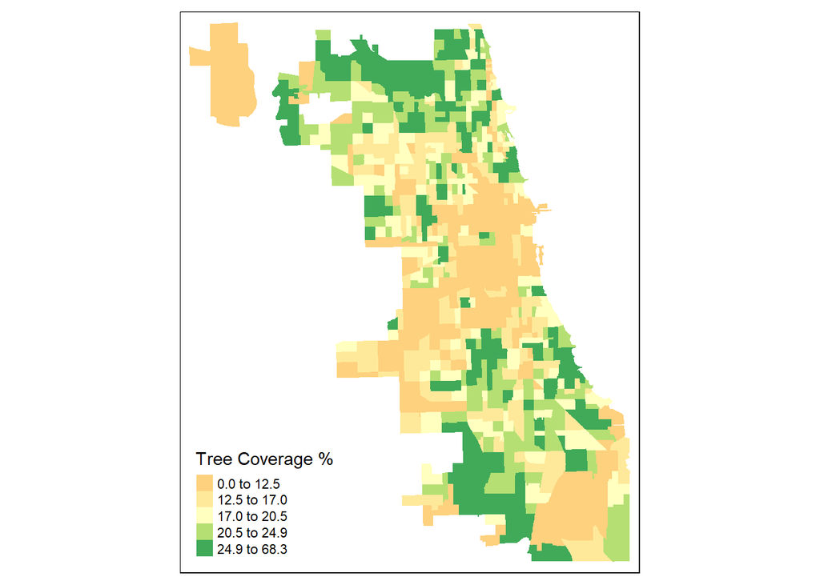

```r
tm_shape(chives) + tm_fill("trees_crown_den",
                           style = "quantile",
                           palette = "RdYlGn",
                           title = "Tree Coverage %")
```

Let’s explore data breaks further. Here’s one way of selecting all census tracts that have less than 10% of its area covered by trees:

```r
fewTrees = chives %>%
  filter(trees_crown_den < 10)

#head(fewTrees)
```

82 features were selected, meaning 82 out of all census tracts in the city have less than 10% of their areas covered by trees.